# Question

A continuous random variable was measured 300 times. The resulting histogram is shown below.

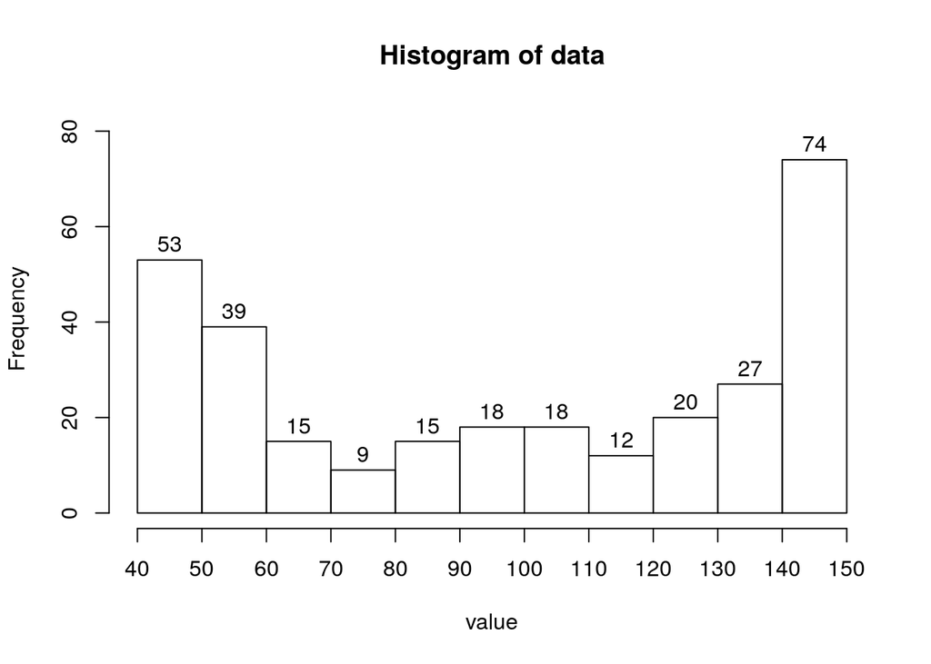

## Answerlist

- Describe the overall shape of the distribution. (symmetric mound, skew left, skew right, uniform, or bimodal)
- Estimate the range of the distribution (range = max-min).
- What percent of the measurements are greater than 110?
- What percent of the measurements are greater than 140?
- What percent of the measurements are between 110 and 140?
- What percent of the measurements are within 5 from 105? In other words, what percent of measurements satisfy $|x-105| \le 5$?
- Of the measurements greater than 110, what percent are greater than 140?
- Estimate the value of the 66.33th percentile. In other words, determine a value such that 66.33% of the measurements are less than or equal to it.

# Solution

## Answerlist

- bimodal
- 110
- 44.33%
- 24.67%
- 19.67%
- 6%
- 55.64%
- 130

# Meta-information

extype: cloze exsolution: bimodal|110|0.4433|0.2467|0.1967|0.06|0.5564|130 exclozetype: string|num|num|num|num|num|num|num exname: reading hist extol: 0.01